# Problems

## Problem 1

Find the currents going through R2 and R4 in the following circuit

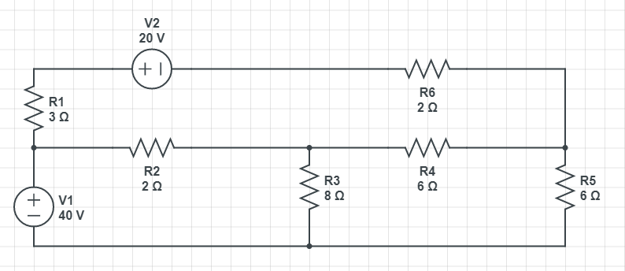

**Solution**

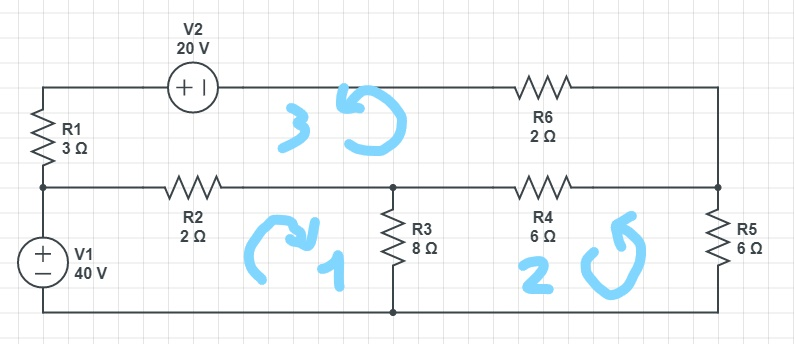

Mesh equations: $$ \begin{array}{l} \left(2 I_{1}+2 I_{3}\right)+\left(8 I_{1}+8 I_{2}\right)=40 \\ \left(8 I_{2}+8 I_{1}\right)+\left(6 I_{2}\right)+\left(6 I_{2}-6 I_{3}\right)=0 \\ \left(2 I_{3}+2 I_{1}\right)+\left(6 I_{3}-6 I_{2}\right)+\left(2 I_{3}\right)+\left(3 I_{3}\right)=20 \end{array} $$ Hence, $$ \begin{array}{l} 10 I_{1}+8 I_{2}+2 I_{3}=40 \\ 8 I_{1}+20 I_{2}-6 I_{3}=0 \\ 2 I_{1}-6 I_{2}+13 I_{3}=20 \end{array} $$ which leads to, $$ I_{1}=6,34 \mathrm{A}, I_{2}=-2,75 \mathrm{A}, I_{3}=-0,71 \mathrm{A} $$ Finally $$ I_{R2}=I_{1}+I_{3}=5,63 \mathrm{A}\\ I_{R4}=I_{3}-I_{2}=2,04 \mathrm{A} $$

```python
from numpy.linalg import solve
```

```python
A=np.matrix('10,8,2;8,20,-6;2,-6,13')
b=np.matrix('40;0;20')
x=solve(A,b)
print(x)
```

```
[[ 6.33802817]
 [-2.74647887]
 [-0.70422535]]
```

```python
A=np.matrix('10,-8,-2;-8,20,-6;-2,-6,13')
b=np.matrix('40;0;-20')
x=solve(A,b)
print(x)
```

```
[[6.33802817]
 [2.74647887]
 [0.70422535]]
```

```python
 (6.33802817-0.70422535)*2+(6.33802817-2.74647887)*8
```

```
40.00000004
```

## Problem 2

Find the current going through R4 in the following circuit

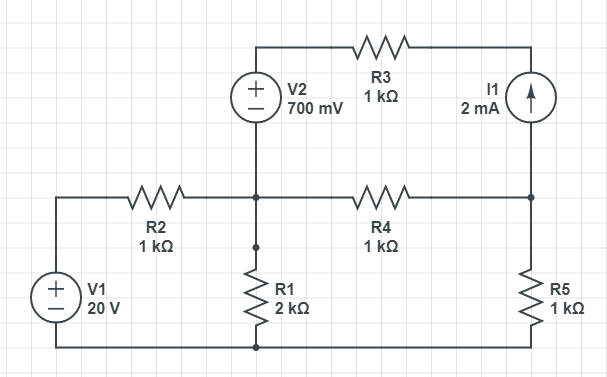

**Solution**

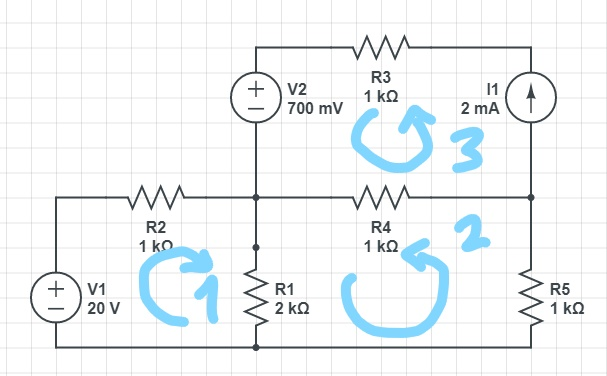

Mesh equations $$ \begin{array}{l} \left(1 I_{1}\right)+\left(2 I_{1}+2 I_{2}\right)=20 \\ \left(2 I_{2}+2 I_{1}\right)+\left(1 I_{2}\right)+\left(1 I_{2}-1 I_{3}\right)=0\\ I_3=2mA \end{array} $$ Then,

$$ \begin{array}{l} 3 I_{1}+2 I_{2}=20 \\ 2 I_{1}+4 I_{2}-I_{3}=0 \\ I_{3}=2 \end{array} $$

The solution to the system of equations is, $$ I_{1}=9,5 \mathrm{mA}, I_{2}=-4,25 \mathrm{mA}, I_{3}=2 \mathrm{mA} $$ Then $$I_{R4}=I_3-I_2=6,25\mathrm{mA}$$

```python
A=np.matrix('3,2,0;2,4,-1;0,0,1')
b=np.matrix('20;0;2')
x=solve(A,b)
print(x)
```

```
[[ 9.5 ]
 [-4.25]
 [ 2.  ]]
```

## Problem 3

Find the current and voltage drop in through R4 in the following circuit. How many nodes are there?

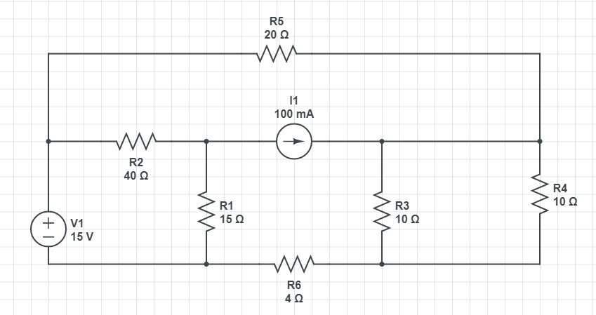

**Solution**

Let's apply mesh analysis for the three lower meshes and the outer loop, assuming they are all clockwise. The equations are:

$$ \begin{array}{l} I_1(40+15)+I_2(-15)=15 \\ I_2=0.1\\ I_2(-10)+I_3(20)+I_4(10)=0 \\ I_2(4)+I_3(10)+I_4(20+10+4)=15 \\ \end{array} $$

```python
A=np.matrix('55,-15,0,0;0,1,0,0;0,-10,20,10;0,4,10,34')
b=np.matrix('15;0.1;0;15')
x=solve(A,b)
print(x)
```

```
[[ 0.3       ]
 [ 0.1       ]
 [-0.19310345]
 [ 0.4862069 ]]
```

$I_{R4}=I_3+I_4=0.29A$

$\Delta V_{R4}=I_{R4}R_4=0.29\times10=2.9V$

*Alternative solution*: Let's combine R3 and R4 as they are in parallel, so $R_{eq}=(R_3R_4)/(R_3+R_4)=100/20=5\Omega$. It is not required, but we simplify the analysis as we now require 3 equations instead of 4. Now there are only 3 meshes.Using the outer loop instead of mesh 3

```python
A=np.matrix('55,-15,-40;0,1,0;0,9,29')
b=np.matrix('15;0.1;15')
x=solve(A,b)
print(x)
```

```
[[0.65360502]
 [0.1       ]
 [0.4862069 ]]
```

The net current is going though $R_4$ is then $I_{R_4}=(I_2+I_3)R_{eq}/R_4=0.29A$, which is the same as our previous result.

## Problem 4

Find the Thevenin's equivalent between A and B

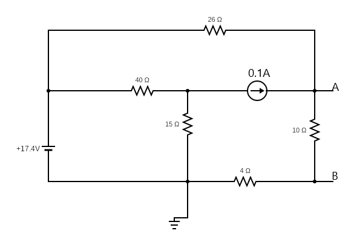

**Solution**

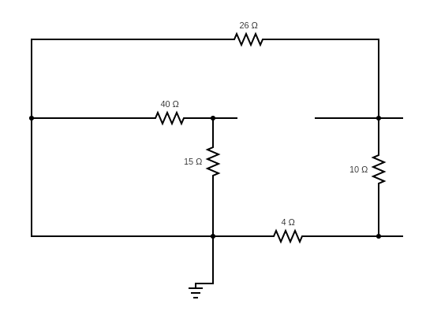

```python
A=np.matrix('55,-15,0;0,1,0;0,14,40')
b=np.matrix('17.4;0.1;17.4')
x=solve(A,b)
print(x)
```

```
[[0.34363636]
 [0.1       ]
 [0.4       ]]
```

## Problem 5

Find the Thevenin's equivalent between A and B

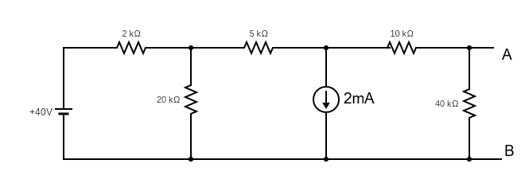

**Answer**

```python
A=np.matrix('22,-20,-20;0,1,0;-20,25,75')
b=np.matrix('40;2;0')
x=solve(A,b)
print(x)
```

```
[[4. ]
 [2. ]
 [0.4]]
```

$$ I_{1}=4 \mathrm{mA} ; I_{2}=2 \mathrm{mA} ; I_{3}=0.4 \mathrm{mA} $$

Hence $$ V_{th}=40k\Omega\cdot I_{3}=16V $$

```python
40*0.4
```

```
16.0
```

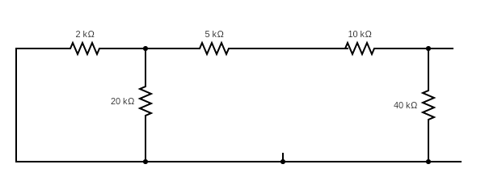

$R_{th}=11.84k\Omega$

```python
parallel1=20*2/(20+2)
series1=parallel1+10+5
parallel2=(series1)*40/(series1+40)
print(parallel2)
```

```
11.84
```